# intermediateR.Rmd

# Intermediate R

The goal of this workshop is to build on R fundamentals we began in the Introduction to R class. In that class we learned how to read and write files, what objects, are, tidy data (long vs. wide form objects), and how to transform data objects using dplyr commands. This workshop will briefly review those topics and build upon them by introducing object filtering, summarizing and aggregating data, how to merge tables, loops, basic statistics, writing functions, and R scripts.

First, we need to set up our working environment. As in the Introduction to R course, we will set our working directory, load the **tidyverse** package, and source the **prep_data.R** script in order to load datasets for us to work with.

```r
setwd('~/Dropbox/Informatics/Workshops/IntermediateR/')
library(tidyverse)
source("prep_data.R")
```

```
##
##  /var/folders/83/dwxgsccn6x12_m61s_kvgljc0000gp/T//RtmpWkK02s/downloaded_packages
```

## Review: tidy data and data transformation with dplyr

### Tidy data

When working wtih a dataset, the shape of the data can be described by *long form* or *wide form*. In general, the preferred data format is long form data (also called tidy data), where each variable is in its own column, and each observation, or case, is in its own row. When data are organized this way, it is easy to access variables as vectors, or filter by categories.

We can use the `gather()` function to change wide form data to long form data, and `spread()` to change long form data to wide form data.

We currently have loaded a tibble called **uscity** that contains the population of for US cities in 2000 and 2010. By printing the data to screen, we can see that it is currently in long form, with each observation (city by year) having its own row, with the varaible (poplation), in a single column.

```r
uscity
```

```
## # A tibble: 522 x 4
##           city state  Year     pop
##          <chr> <chr> <dbl>   <dbl>
##  1     Abilene    TX  2000  115930
##  2     Abilene    TX  2010  117063
##  3       Akron    OH  2000  787289
##  4       Akron    OH  2010  199110
##  5 Albuquerque    NM  2000 1046798
##  6 Albuquerque    NM  2010  545852
##  7  Alexandria    VA  2000  128283
##  8  Alexandria    VA  2010  139966
##  9   Allentown    PA  2000  683040
## 10   Allentown    PA  2010  118032
## # ... with 512 more rows
```

We can use `spread()` to convert this to wide form data, to display the population per year in two separate columns.

```r
uscity_wide <- uscity %>%
  spread(key=Year, value=pop)
uscity_wide
```

```
## # A tibble: 285 x 4
##           city state  `2000` `2010`
##  *       <chr> <chr>   <dbl>  <dbl>
##  1     Abilene    TX  115930 117063
##  2       Akron    OH  787289 199110
##  3 Albuquerque    NM 1046798 545852
##  4  Alexandria    VA  128283 139966
##  5   Allentown    PA  683040 118032
##  6    Amarillo    TX  352939 190695
##  7     Anaheim    CA  328014 336265
##  8   Anchorage    AK  260283 291826
##  9   Ann Arbor    MI  397928 113934
## 10     Antioch    CA      NA 102372
## # ... with 275 more rows
```

We can use `gather()` to return this to long form.

```r
uscity_long <- uscity_wide %>%
  gather(key=Year,value=pop,-city,-state)
uscity_long
```

```
## # A tibble: 570 x 4
##           city state  Year     pop
##          <chr> <chr> <chr>   <dbl>
##  1     Abilene    TX  2000  115930
##  2       Akron    OH  2000  787289
##  3 Albuquerque    NM  2000 1046798
##  4  Alexandria    VA  2000  128283
##  5   Allentown    PA  2000  683040
##  6    Amarillo    TX  2000  352939
##  7     Anaheim    CA  2000  328014
##  8   Anchorage    AK  2000  260283
##  9   Ann Arbor    MI  2000  397928
## 10     Antioch    CA  2000      NA
## # ... with 560 more rows
```

Recall that two other useful functions in the tidy package are `unite()`, which can be used to combine two columns into one, and `separate()`, which can be used to split one column into two.

To demonstrate, let’s first combine the city and state columns into one, separated by “,”.

```r
uscity_long <- uscity_long %>%
  unite(city, state, col="location", sep=", ", remove=TRUE)
uscity_long
```

```
## # A tibble: 570 x 3
##           location  Year     pop
##  *           <chr> <chr>   <dbl>
##  1     Abilene, TX  2000  115930
##  2       Akron, OH  2000  787289
##  3 Albuquerque, NM  2000 1046798
##  4  Alexandria, VA  2000  128283
##  5   Allentown, PA  2000  683040
##  6    Amarillo, TX  2000  352939
##  7     Anaheim, CA  2000  328014
##  8   Anchorage, AK  2000  260283
##  9   Ann Arbor, MI  2000  397928
## 10     Antioch, CA  2000      NA
## # ... with 560 more rows
```

Now let’s separate that location column back into city and state with `separate()`.

```r
uscity_long <- uscity_long %>%
  separate(location, into=c("city","state"), sep=", ", remove=TRUE)
uscity_long
```

```
## # A tibble: 570 x 4
##           city state  Year     pop
##  *       <chr> <chr> <chr>   <dbl>
##  1     Abilene    TX  2000  115930
##  2       Akron    OH  2000  787289
##  3 Albuquerque    NM  2000 1046798
##  4  Alexandria    VA  2000  128283
##  5   Allentown    PA  2000  683040
##  6    Amarillo    TX  2000  352939
##  7     Anaheim    CA  2000  328014
##  8   Anchorage    AK  2000  260283
##  9   Ann Arbor    MI  2000  397928
## 10     Antioch    CA  2000      NA
## # ... with 560 more rows
```

### Data Transformation

In Introduction to R, we also learned several functions to transform data matrices (tibbles) with dplyr. Here we will briefly review them.

The `arrange()` function can be used to reorder data. Let’s rearrange our uscity_long tibble so that the order matches the original uscity tibble.

```r
uscity_long %>%
  arrange(city)
```

```
## # A tibble: 570 x 4
##           city state  Year     pop
##          <chr> <chr> <chr>   <dbl>
##  1     Abilene    TX  2000  115930
##  2     Abilene    TX  2010  117063
##  3       Akron    OH  2000  787289
##  4       Akron    OH  2010  199110
##  5 Albuquerque    NM  2000 1046798
##  6 Albuquerque    NM  2010  545852
##  7  Alexandria    VA  2000  128283
##  8  Alexandria    VA  2010  139966
##  9   Allentown    PA  2000  683040
## 10   Allentown    PA  2010  118032
## # ... with 560 more rows
```

By adding the `desc()` function to the arrange call, we can reverse the order.

```r
uscity_long %>%
  arrange(desc(city))
```

```
## # A tibble: 570 x 4
##             city state  Year    pop
##            <chr> <chr> <chr>  <dbl>
##  1       Yonkers    NY  2000 196086
##  2       Yonkers    NY  2010 195976
##  3     Worcester    MA  2000 602530
##  4     Worcester    MA  2010 181045
##  5 Winston-salem    NC  2000 485066
##  6 Winston-salem    NC  2010 229617
##  7    Wilmington    NC  2000     NA
##  8    Wilmington    NC  2010 106476
##  9 Wichita Falls    TX  2000 104197
## 10 Wichita Falls    TX  2010 104553
## # ... with 560 more rows
```

The `select()` function can be used to select columns of the tibble, and can also be used to rename columns (remember the `rename()` fuction can also do this specifically). Keep in mind that you can select all columns, but in a different order, if you simply want to rearrange your columns.

For example, let’s rearrange the uscity_long columns, and rename pop to population and Year to year.

```r
uscity_long %>%
  select(year = Year, state, city, population = pop)
```

```
## # A tibble: 570 x 4
##     year state        city population
##  * <chr> <chr>       <chr>      <dbl>
##  1  2000    TX     Abilene     115930
##  2  2000    OH       Akron     787289
##  3  2000    NM Albuquerque    1046798
##  4  2000    VA  Alexandria     128283
##  5  2000    PA   Allentown     683040
##  6  2000    TX    Amarillo     352939
##  7  2000    CA     Anaheim     328014
##  8  2000    AK   Anchorage     260283
##  9  2000    MI   Ann Arbor     397928
## 10  2000    CA     Antioch         NA
## # ... with 560 more rows
```

The `distinct()` function can be used to identify all unique values in a column. For example, we can find all of the unique values in the year column.

```r
uscity_long %>%
  select(Year) %>%
  distinct()
```

```
## # A tibble: 2 x 1
##    Year
##   <chr>
## 1  2000
## 2  2010
```

Finally, the `mutate()` function can be used to create or update a column. Let’s round the pop colum to the nearest thousand.

```r
uscity_long %>%
  mutate(pop = round(pop,digits = -3))
```

```
## # A tibble: 570 x 4
##           city state  Year     pop
##          <chr> <chr> <chr>   <dbl>
##  1     Abilene    TX  2000  116000
##  2       Akron    OH  2000  787000
##  3 Albuquerque    NM  2000 1047000
##  4  Alexandria    VA  2000  128000
##  5   Allentown    PA  2000  683000
##  6    Amarillo    TX  2000  353000
##  7     Anaheim    CA  2000  328000
##  8   Anchorage    AK  2000  260000
##  9   Ann Arbor    MI  2000  398000
## 10     Antioch    CA  2000      NA
## # ... with 560 more rows
```

### Review Exercises

> Create a cleaned version of the housing dataset (called housing_clean). This will require a series of dplyr functions, chained together by pipes (`%>%`). We will work through each of these steps together to build our dataset. The steps are to:
> 1. convert housing to a tibble
> 2. convert to long form using gather, with location as the key and local_index as the value. Make sure to keep Date and National.US separate.
> 3. convert location into state and city (remember, you need to do something to account for the extra space between city names). Be sure to remove the original location name
> 4. convert date into year and month (remember, we don’t need the extra date)
> 5. Rearrange the colums to be year, month, city, state, local_index and National.US (renamed national_index)
> 6. arrange in order or year, month, state and finally city
> 7. change year into an integer, use the month.abb vector to change the month integer to a name, change the city names to have “.” between the words to include “_“s instead (use the sub function), and finally, calculate a relative index (rel_index) by dividing the local_index by the national_index.

```r
housing_clean <- housing %>%
  as.tibble %>%
  gather(location, local_index, -Date, -National.US) %>%
  separate(location, c("state", "city"),extra="merge") %>%
  separate(Date, c("year", "month"), extra="drop", remove=F) %>%
  select(year, month, city, state, local_index, national_index=National.US) %>%
  arrange(year, month, state, city) %>%
  mutate(year = as.integer(year), month = month.abb[as.integer(month)], city = sub(".", "_", city, fixed=TRUE), rel_index = local_index/national_index)
```

## Filtering functions

Sometiems we need to filter datasets, and we can do this by selecting rows that meet logical conditions. We set these up with logical tests.

The filter() function can be used to select rows meeting these conditions:

```r
housing_clean %>%
  filter(city == "Boston")
```

```
## # A tibble: 348 x 7
##     year month   city state local_index national_index rel_index
##    <int> <chr>  <chr> <chr>       <dbl>          <dbl>     <dbl>
##  1  1987   Jan Boston    MA       70.04          63.75  1.098667
##  2  1987   Feb Boston    MA       70.08          64.15  1.092440
##  3  1987   Mar Boston    MA       70.00          64.49  1.085440
##  4  1987   Apr Boston    MA       70.70          64.99  1.087860
##  5  1987   May Boston    MA       71.51          65.57  1.090590
##  6  1987   Jun Boston    MA       72.32          66.24  1.091787
##  7  1987   Jul Boston    MA       73.09          66.80  1.094162
##  8  1987   Aug Boston    MA       73.79          67.29  1.096597
##  9  1987   Sep Boston    MA       74.39          67.64  1.099793
## 10  1987   Oct Boston    MA       74.63          67.92  1.098793
## # ... with 338 more rows
```

We can give filter many logical tests, all separated by commas. These are linked by logical and (all must be true to select that row):

```r
housing_clean %>%
  filter(city=="Boston", month=="Aug")
```

```
## # A tibble: 29 x 7
##     year month   city state local_index national_index rel_index
##    <int> <chr>  <chr> <chr>       <dbl>          <dbl>     <dbl>
##  1  1987   Aug Boston    MA       73.79          67.29 1.0965968
##  2  1988   Aug Boston    MA       75.47          72.19 1.0454357
##  3  1989   Aug Boston    MA       74.07          76.28 0.9710278
##  4  1990   Aug Boston    MA       69.56          77.47 0.8978960
##  5  1991   Aug Boston    MA       64.79          76.59 0.8459329
##  6  1992   Aug Boston    MA       64.75          76.74 0.8437581
##  7  1993   Aug Boston    MA       66.62          78.14 0.8525723
##  8  1994   Aug Boston    MA       69.27          80.33 0.8623179
##  9  1995   Aug Boston    MA       71.04          81.68 0.8697356
## 10  1996   Aug Boston    MA       73.98          83.68 0.8840822
## # ... with 19 more rows
```

If we want to use other booleans, just put them in one statement, e.g.:

```r
housing_clean %>%
  filter(city=="Boston", month == "Aug" | month == "Jan")
```

```
## # A tibble: 58 x 7
##     year month   city state local_index national_index rel_index
##    <int> <chr>  <chr> <chr>       <dbl>          <dbl>     <dbl>
##  1  1987   Jan Boston    MA       70.04          63.75 1.0986667
##  2  1987   Aug Boston    MA       73.79          67.29 1.0965968
##  3  1988   Jan Boston    MA       74.40          68.60 1.0845481
##  4  1988   Aug Boston    MA       75.47          72.19 1.0454357
##  5  1989   Jan Boston    MA       74.23          73.62 1.0082858
##  6  1989   Aug Boston    MA       74.07          76.28 0.9710278
##  7  1990   Jan Boston    MA       72.76          76.53 0.9507383
##  8  1990   Aug Boston    MA       69.56          77.47 0.8978960
##  9  1991   Jan Boston    MA       64.97          75.53 0.8601880
## 10  1991   Aug Boston    MA       64.79          76.59 0.8459329
## # ... with 48 more rows
```

Note that we can combine filters and the other statements to get useful subsets, for example let’s say we want to see three years when the relative index in Boston was the highest (as of Jan):

```r
housing_clean %>%
  filter(city=="Boston", month=="Jan") %>%
  arrange(desc(rel_index)) %>%
  select(year,rel_index) %>%
  head(n=3)
```

```
## # A tibble: 3 x 2
##    year rel_index
##   <int>     <dbl>
## 1  2003  1.149941
## 2  2004  1.126715
## 3  2002  1.115854
```

Finally, many times you want to filter out missing data (typically indicated by `NA` in R), prior to conducting any analyses. To do this, we an use the `is.na()` fuction, which will return a vector with TRUE if NA is present, and FALSE otherwise. For example, let’s identify all rows that are missing the local_index in housing_clean.

```r
housing_clean %>%
  filter(is.na(local_index))
```

```
## # A tibble: 336 x 7
##     year month        city state local_index national_index rel_index
##    <int> <chr>       <chr> <chr>       <dbl>          <dbl>     <dbl>
##  1  1987   Jan     Phoenix    AZ          NA          63.75        NA
##  2  1987   Jan     Atlanta    GA          NA          63.75        NA
##  3  1987   Jan     Detroit    MI          NA          63.75        NA
##  4  1987   Jan Minneapolis    MN          NA          63.75        NA
##  5  1987   Jan      Dallas    TX          NA          63.75        NA
##  6  1987   Jan     Seattle    WA          NA          63.75        NA
##  7  1987   Feb     Phoenix    AZ          NA          64.15        NA
##  8  1987   Feb     Atlanta    GA          NA          64.15        NA
##  9  1987   Feb     Detroit    MI          NA          64.15        NA
## 10  1987   Feb Minneapolis    MN          NA          64.15        NA
## # ... with 326 more rows
```

To get the inverse for this (or any logical statement), simply add a `!` to the front.

```r
housing_clean %>%
  filter(!is.na(local_index))
```

```
## # A tibble: 6,624 x 7
##     year month          city state local_index national_index rel_index
##    <int> <chr>         <chr> <chr>       <dbl>          <dbl>     <dbl>
##  1  1987   Jan   Los_Angeles    CA       59.33          63.75 0.9306667
##  2  1987   Jan     San_Diego    CA       54.67          63.75 0.8575686
##  3  1987   Jan San_Francisco    CA       46.61          63.75 0.7311373
##  4  1987   Jan        Denver    CO       50.20          63.75 0.7874510
##  5  1987   Jan    Washington    DC       64.11          63.75 1.0056471
##  6  1987   Jan         Miami    FL       68.50          63.75 1.0745098
##  7  1987   Jan         Tampa    FL       77.33          63.75 1.2130196
##  8  1987   Jan       Chicago    IL       53.55          63.75 0.8400000
##  9  1987   Jan        Boston    MA       70.04          63.75 1.0986667
## 10  1987   Jan     Charlotte    NC       63.39          63.75 0.9943529
## # ... with 6,614 more rows
```

## Exercises using dpylr functions to manipulate datasets

We’ll turn to another dataset, this one packaged with R, in order to try some exercises with these functions. The data we’ll look at is a dataset of all flights leaving New York City airports in 2013, in the tibble flights. First take a minute just to see what is there.

### Exercise 1:

Sort the dataset (called flights) from longest to shortest air time. What is the longest flight from NYC and where does it go? Hint: Use arrange and select

```r
flights %>%
  arrange(desc(air_time)) %>%
  select(air_time,dest) %>% head(n=1)
```

```
## # A tibble: 1 x 2
##   air_time  dest
##      <dbl> <chr>
## 1      695   HNL
```

### Exercise 2:

Look at just the origin, destination, month, and carrier for the 10 shortest flights (keeping air_time in the output)

```r
flights %>%
  arrange(air_time) %>%
  select(origin, dest, month, carrier, air_time) %>%
  head(n=10)
```

```
## # A tibble: 10 x 5
##    origin  dest month carrier air_time
##     <chr> <chr> <int>   <chr>    <dbl>
##  1    EWR   BDL     1      EV       20
##  2    EWR   BDL     4      EV       20
##  3    EWR   BDL    12      EV       21
##  4    EWR   PHL     2      EV       21
##  5    EWR   BDL     2      EV       21
##  6    EWR   PHL     2      EV       21
##  7    LGA   BOS     3      US       21
##  8    JFK   PHL     3      9E       21
##  9    EWR   BDL     3      EV       21
## 10    EWR   BDL     3      EV       21
```

### Exercise 3:

Look at just flights leaving from JFK, use the same columns as exercise 2, but this time get the 10 longest arrival delays, renaming the arr_delay column in the output to minutes_delayed

```r
flights %>%
  filter(origin=="JFK") %>%
  arrange(desc(arr_delay)) %>%
  select(origin, dest, month, carrier, minutes_delayed=arr_delay) %>%
  head(n=10)
```

```
## # A tibble: 10 x 5
##    origin  dest month carrier minutes_delayed
##     <chr> <chr> <int>   <chr>           <dbl>
##  1    JFK   HNL     1      HA            1272
##  2    JFK   CMH     6      MQ            1127
##  3    JFK   SFO     9      AA            1007
##  4    JFK   CVG     7      MQ             989
##  5    JFK   TPA     4      DL             931
##  6    JFK   TPA    12      DL             856
##  7    JFK   LAS     5      AA             852
##  8    JFK   BWI     1      MQ             851
##  9    JFK   PDX     6      DL             850
## 10    JFK   LAX     3      DL             784
```

### Exercise 4:

Repeat exercise 3, but this time convert arr_delay to hours_delayed using mutate(), and month to a name instead of an interger (remember month.name[1] == “January”)

```r
flights %>%
  filter(origin=="JFK") %>%
  arrange(desc(arr_delay)) %>%
  mutate(month=month.name[month], hours_delayed = arr_delay/60) %>%
  select(origin, dest, month, carrier, hours_delayed) %>%
  head(n=10)
```

```
## # A tibble: 10 x 5
##    origin  dest     month carrier hours_delayed
##     <chr> <chr>     <chr>   <chr>         <dbl>
##  1    JFK   HNL   January      HA      21.20000
##  2    JFK   CMH      June      MQ      18.78333
##  3    JFK   SFO September      AA      16.78333
##  4    JFK   CVG      July      MQ      16.48333
##  5    JFK   TPA     April      DL      15.51667
##  6    JFK   TPA  December      DL      14.26667
##  7    JFK   LAS       May      AA      14.20000
##  8    JFK   BWI   January      MQ      14.18333
##  9    JFK   PDX      June      DL      14.16667
## 10    JFK   LAX     March      DL      13.06667
```

### Exercise 5:

Repeat exercise 4, but this time get delays for just winter months (Dec, Jan, Feb), from JFK or LGA but not Newark (EWR), and only for United (UA), Delta (DL), and American (AA), and sort the top 10 by carrier.

Hint: flights %>% slice(1:10) returns a tibble, as does head(n=10)

```r
flights %>%
  filter(origin=="JFK" | origin=="LGA", month %in% c(1,2,12), carrier %in% c("UA", "DL", "AA")) %>%
  arrange(desc(arr_delay)) %>%
  mutate(month=month.name[month], hours_delayed = arr_delay/60) %>%
  select(origin, dest, month, carrier, hours_delayed) %>%
  slice(1:10) %>%
  arrange(carrier)
```

```
## # A tibble: 10 x 5
##    origin  dest    month carrier hours_delayed
##     <chr> <chr>    <chr>   <chr>         <dbl>
##  1    LGA   MIA December      AA     10.800000
##  2    LGA   MIA December      AA      6.616667
##  3    JFK   SFO  January      AA      6.133333
##  4    JFK   TPA December      DL     14.266667
##  5    LGA   MSP February      DL     12.783333
##  6    JFK   SAT December      DL     11.350000
##  7    JFK   ATL  January      DL     10.200000
##  8    LGA   MSP  January      DL      8.100000
##  9    JFK   ATL December      DL      6.500000
## 10    LGA   ORD  January      UA      6.566667
```

## Summarzing and aggregating data

Once you have your data organized, you can use the summarize function in dplyr, along with the group_by helper function, to do a lot of powerful stuff.

We’ll continue to explore our mms dataset to demonstrate.

Okay, now what can we do with summarize? First, let’s just get the total number of M&Ms in this dataset:

```r
mms %>% summarize(total_mms=sum(count))
```

```
## # A tibble: 1 x 1
##   total_mms
##       <int>
## 1      1713
```

The group_by function allows us to assign groups, which will then be “unwound” by summarize statements. Easiest to see by example:

```r
mms %>%
  group_by(BagID) %>%
  summarize(mms_per_bag=sum(count)) %>% print %>% summarize(total_mms=sum(mms_per_bag))
```

```
## # A tibble: 30 x 2
##    BagID mms_per_bag
##    <int>       <int>
##  1     1          58
##  2     2          59
##  3     3          59
##  4     4          57
##  5     5          55
##  6     6          58
##  7     7          58
##  8     8          61
##  9     9          58
## 10    10          53
## # ... with 20 more rows
```

```
## # A tibble: 1 x 1
##   total_mms
##       <int>
## 1      1713
```

```r
mms %>%
  group_by(color) %>%
  summarize(mms_per_color=sum(count)) %>% print %>% summarize(total_mms=sum(mms_per_color))
```

```
## # A tibble: 6 x 2
##    color mms_per_color
##    <chr>         <int>
## 1   Blue           217
## 2  Brown           374
## 3  Green           222
## 4 Orange           199
## 5    Red           288
## 6 Yellow           413
```

```
## # A tibble: 1 x 1
##   total_mms
##       <int>
## 1      1713
```

Note that summarize outputs a new tibble. You can continue to do calculations on this tibble (for example, if you data has many layers), but you cannot call your original tibble again within the same set of pipes.

We can do some tricky stuff with summarize, group_by, and mutate. For example, let’s get the fraction of each color in each bag:

```r
mms %>%
  group_by(BagID) %>%
  mutate(percent = 100*(count/sum(count))) %>%
  select(-count) %>%
  spread(color, percent)
```

```
## # A tibble: 30 x 8
## # Groups:   BagID [30]
##    Weight BagID      Blue     Brown     Green    Orange       Red   Yellow
##  *  <dbl> <int>     <dbl>     <dbl>     <dbl>     <dbl>     <dbl>    <dbl>
##  1  46.22    10  5.660377 28.301887 16.981132 16.981132 16.981132 15.09434
##  2  46.72    26 12.500000 33.928571 10.714286 10.714286  7.142857 25.00000
##  3  46.94    13 23.636364 23.636364 16.363636  3.636364 21.818182 10.90909
##  4  47.61     5 12.727273  7.272727  5.454545 16.363636 18.181818 40.00000
##  5  47.67    27 19.298246 12.280702 21.052632 10.526316 17.543860 19.29825
##  6  47.70    28  3.703704 29.629630  7.407407 16.666667  9.259259 33.33333
##  7  47.98    14 14.000000 14.000000 14.000000  4.000000 18.000000 36.00000
##  8  48.28    24  1.785714 33.928571 10.714286 21.428571 21.428571 10.71429
##  9  48.33    16 16.363636 36.363636 10.909091  7.272727  7.272727 21.81818
## 10  48.45     9 17.241379 31.034483  3.448276 10.344828  6.896552 31.03448
## # ... with 20 more rows
```

Note there is some subtle stuff going on here. When we us mutant on a grouped tibble, operations like sum() work **within the grouping**. So sum(count) computes the group-wise sum, which means it is easy to get frequencies or percents.

We can then use this insight to explore the data. For example, let’s get the 5 bags of M&Ms with the highest percentage of red candies, conditioning on a weight of at least 47g:

```r
mms %>%
  group_by(BagID) %>%
  mutate(percent = 100*(count/sum(count))) %>%
  select(-count) %>%
  filter(color == "Red", Weight > 47) %>%
  arrange(desc(percent)) %>%
  head(n=5)
```

```
## # A tibble: 5 x 4
## # Groups:   BagID [5]
##   Weight BagID color  percent
##    <dbl> <int> <chr>    <dbl>
## 1  50.01    23   Red 35.71429
## 2  49.16     4   Red 26.31579
## 3  49.79     1   Red 25.86207
## 4  49.40    29   Red 25.86207
## 5  49.69    18   Red 24.13793
```

Note that we can send this to plotting functions like so:

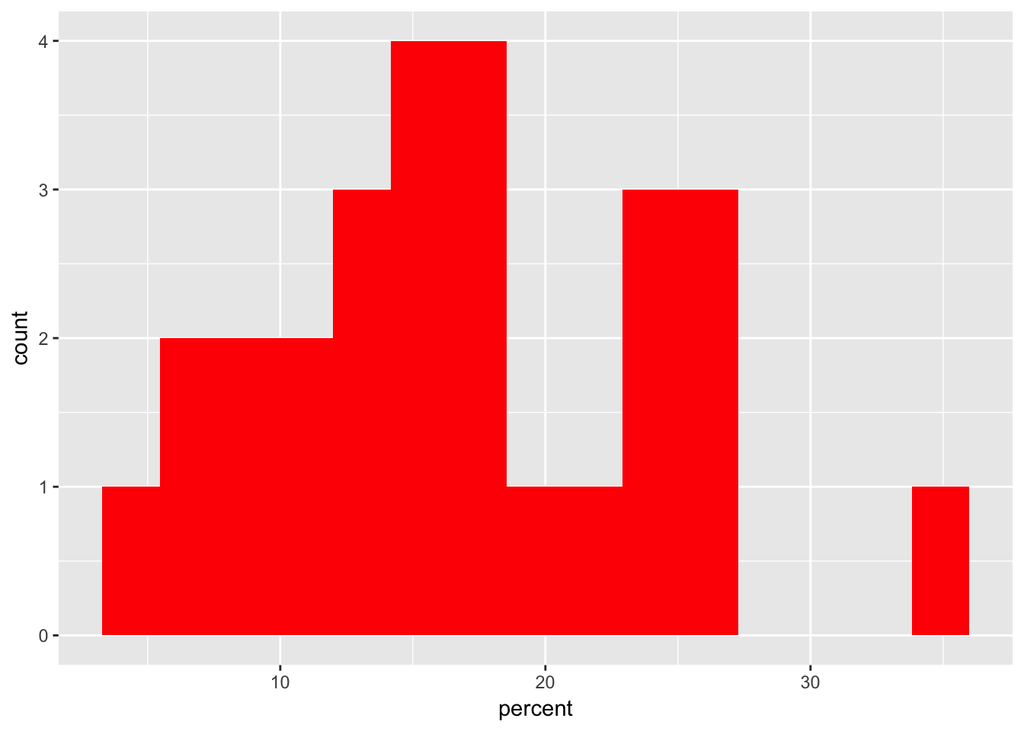

```r
mms %>%
  group_by(BagID) %>%
  mutate(percent = 100*(count/sum(count))) %>%
  select(-count) %>%
  filter(color == "Red", Weight > 47) %>%
  ggplot(aes(percent)) +
  geom_histogram(bins=15,fill="red")
```

## Exercises with summarize and group_by

### Exercise 1:

Using the housing_clean dataset, find the three cities with the highest relative index in February, averaged across the years. Hint: first filter by month and filter out all values that have missing data with `!is.na()`, then summarize by city using the `mean()` function.

```r
housing_clean %>%
  filter(month=="Feb", !is.na(rel_index)) %>%
  group_by(city) %>%
  summarize(mean_rel_index = mean(rel_index)) %>%
  arrange(desc(mean_rel_index)) %>%
  head(n=3)
```

```
## # A tibble: 3 x 2
##          city mean_rel_index
##         <chr>          <dbl>
## 1  Washington       1.166866
## 2 Los_Angeles       1.149740
## 3       Miami       1.107553
```

### Exercise 2:

Now, how has the relative housing index changed through the years, averaged across cities (call year_mean)? Can you produce a line plot of this change? Hint: First filter out all missing data. To plot, for the aesthetics, set = year and y = year_mean, and use geom_line().

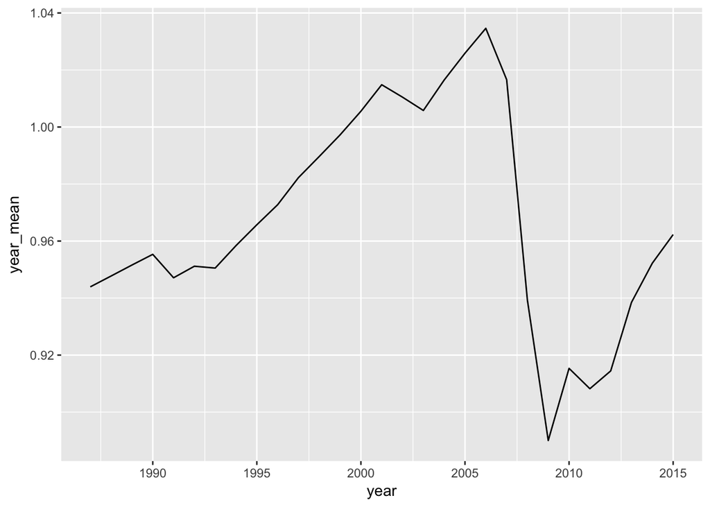

```r
housing_clean %>%
  filter(!is.na(rel_index)) %>%
  group_by(year) %>%
  summarize(year_mean = mean(rel_index)) %>%
  ggplot(aes(x=year,y=year_mean)) +
  geom_line()
```

## Merging data

As a final data processing step, we’ll look at the merge functions in dplyr. These work kind of like sql queries, and take there names from the similar query syntax. All follow the pattern *something*_join. The most common are inner_join, left_join, right_join, and full_join, which keep rows with data in both dataframes, the left dataframe, the right dataframe, or either dataframe, respectively. We’ll look at a couple of examples, and then try a few exercises. Here, we’ll go back to the flights tibble, and use a dataset of US airport codes to add some additional information.

First, let’s just do a join to add the info from US airport codes to the flights dataset, merging on the destination airport.

```r
flights2<-left_join(flights, us_aircodes, by=c("dest" = "iata_code")) %>% print
```

```
## # A tibble: 336,776 x 30
##     year month   day dep_time sched_dep_time dep_delay arr_time
##    <int> <int> <int>    <int>          <int>     <dbl>    <int>
##  1  2013     1     1      517            515         2      830
##  2  2013     1     1      533            529         4      850
##  3  2013     1     1      542            540         2      923
##  4  2013     1     1      544            545        -1     1004
##  5  2013     1     1      554            600        -6      812
##  6  2013     1     1      554            558        -4      740
##  7  2013     1     1      555            600        -5      913
##  8  2013     1     1      557            600        -3      709
##  9  2013     1     1      557            600        -3      838
## 10  2013     1     1      558            600        -2      753
## # ... with 336,766 more rows, and 23 more variables: sched_arr_time <int>,
## #   arr_delay <dbl>, carrier <chr>, flight <int>, tailnum <chr>,
## #   origin <chr>, dest <chr>, air_time <dbl>, distance <dbl>, hour <dbl>,
## #   minute <dbl>, time_hour <dttm>, ident <chr>, type <chr>, name <chr>,
## #   coordinates <chr>, elevation_ft <int>, continent <chr>,
## #   iso_country <chr>, iso_region <chr>, municipality <chr>,
## #   gps_code <chr>, local_code <chr>
```

Doing a left join means we’ll keep all the rows of flights, even if they don’t have a match in us_aircodes, but in theory everything should have a match.

If we wanted to keep everything in us_aircodes, even if you can’t get a direct flight from NYC there, we could use a full join, like so:

```r
flights3 <- flights %>%
  select(origin, dest, carrier, month, day) %>%
  full_join(., us_aircodes, by=c("dest" = "iata_code")) %>%
  select(municipality, state=iso_region, airport=name, origin:type) %>%
  print
```

```
## # A tibble: 338,713 x 10
##       municipality  state                                          airport
##              <chr>  <chr>                                            <chr>
##  1         Houston  US-TX     George Bush Intercontinental Houston Airport
##  2         Houston  US-TX     George Bush Intercontinental Houston Airport
##  3           Miami  US-FL                      Miami International Airport
##  4       Aguadilla PR-U-A                         Rafael Hernandez Airport
##  5         Atlanta  US-GA Hartsfield Jackson Atlanta International Airport
##  6         Chicago  US-IL             Chicago O'Hare International Airport
##  7 Fort Lauderdale  US-FL  Fort Lauderdale Hollywood International Airport
##  8      Washington  US-DC          Washington Dulles International Airport
##  9         Orlando  US-FL                    Orlando International Airport
## 10         Chicago  US-IL             Chicago O'Hare International Airport
## # ... with 338,703 more rows, and 7 more variables: origin <chr>,
## #   dest <chr>, carrier <chr>, month <int>, day <int>, ident <chr>,
## #   type <chr>
```

We can use this to get things like the number of airports of each type you can fly to from NYC.

```r
flights3 %>%
  distinct(origin,dest,type) %>%
  with(., table(origin,type, useNA="always"))
```

```
##       type
## origin heliport large_airport medium_airport seaplane_base small_airport
##   EWR         0            71             14             0             1
##   JFK         0            59             10             0             1
##   LGA         0            58             10             0             0
##   <NA>       20            93            684            75          1065
##       type
## origin <NA>
##   EWR     0
##   JFK     0
##   LGA     0
##   <NA>    0
```

Because we did a full join, we’ll get NAs for type for rows where the dest IATA code was not in our us_aircodes tibble, and NAs for origin for places in the us_aircodes tibble that don’t have direct flights from NYC area airports.

Inner join just keeps things in both tables. We can use this, for example, to just get the flights to small airports from NYC.

```r
us_aircodes %>% filter(type == "small_airport", iata_code != "") %>%
  select(name, municipality, iso_region, iata_code) %>%
  inner_join(., flights, by=c("iata_code" = "dest")) %>% print
```

```
## # A tibble: 236 x 22
##                    name municipality iso_region iata_code  year month
##                   <chr>        <chr>      <chr>     <chr> <int> <int>
##  1 Yampa Valley Airport       Hayden      US-CO       HDN  2013     1
##  2 Yampa Valley Airport       Hayden      US-CO       HDN  2013     1
##  3 Yampa Valley Airport       Hayden      US-CO       HDN  2013     1
##  4 Yampa Valley Airport       Hayden      US-CO       HDN  2013     1
##  5 Yampa Valley Airport       Hayden      US-CO       HDN  2013    12
##  6 Yampa Valley Airport       Hayden      US-CO       HDN  2013    12
##  7 Yampa Valley Airport       Hayden      US-CO       HDN  2013     2
##  8 Yampa Valley Airport       Hayden      US-CO       HDN  2013     2
##  9 Yampa Valley Airport       Hayden      US-CO       HDN  2013     2
## 10 Yampa Valley Airport       Hayden      US-CO       HDN  2013     2
## # ... with 226 more rows, and 16 more variables: day <int>,
## #   dep_time <int>, sched_dep_time <int>, dep_delay <dbl>, arr_time <int>,
## #   sched_arr_time <int>, arr_delay <dbl>, carrier <chr>, flight <int>,
## #   tailnum <chr>, origin <chr>, air_time <dbl>, distance <dbl>,
## #   hour <dbl>, minute <dbl>, time_hour <dttm>
```

### Merging Exercise

You should have a uscity dataset loaded as well. Look at it, then figure out how to add 2010 population figures to the flights database. You can chain joins together, like so: data1 %>% inner_join(., data2) %>% inner_join(., data3). Remember if you don’t specify a by list (in the form by=c(“xname1” = “yname1”, “xname2 = yname2”), joins will attempt a natural merge (join on all matching column names)). In the end, you want all nycflights that have a US destination, but only the city information for those with population information (i.e., don’t keep the aircode information if that city isn’t in the uscity datasets). Think a little bit about what columns you need to keep (all nycflight columns, and at least the city/state/population column from uscity, but others are up to you)

```
## # A tibble: 347,294 x 24
##               city state     pop          type
##              <chr> <chr>   <dbl>         <chr>
##  1         Houston    TX 2099451 large_airport
##  2         Houston    TX 2099451 large_airport
##  3           Miami    FL  399457 large_airport
##  4            <NA>  <NA>      NA          <NA>
##  5         Atlanta    GA  420003 large_airport
##  6         Chicago    IL 2695598 large_airport
##  7 Fort Lauderdale    FL  165521 large_airport
##  8      Washington    DC  601723 large_airport
##  9         Orlando    FL  238300 large_airport
## 10         Chicago    IL 2695598 large_airport
## # ... with 347,284 more rows, and 20 more variables: name <chr>,
## #   iata_code <chr>, year <int>, month <int>, day <int>, dep_time <int>,
## #   sched_dep_time <int>, dep_delay <dbl>, arr_time <int>,
## #   sched_arr_time <int>, arr_delay <dbl>, carrier <chr>, flight <int>,
## #   tailnum <chr>, origin <chr>, air_time <dbl>, distance <dbl>,
## #   hour <dbl>, minute <dbl>, time_hour <dttm>
```

## Statistics

Now let’s demonstrate a few statistical tests.

With our flights dataset, we might want to know if there is any difference between JFK and LGA in distance of flights. Let’s first make a quick boxplot to look at the data.

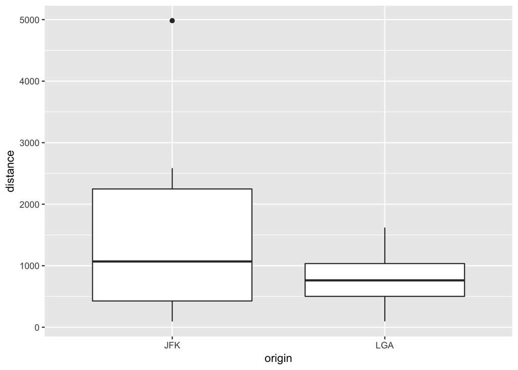

```r
flights %>%
  filter(origin == "JFK" | origin == "LGA") %>%
  ggplot(aes(x=origin,y=distance)) +
  geom_boxplot()
```

Our boxplot suggests that flights that depart from JFK typically travel further distances than those that depart from LGA. Let’s test that using a T-test.

```r
#note that we can use a logical test as a grouping variable in a formula
flights %>%
  filter(origin == "JFK" | origin == "LGA") %>%
  t.test(data=.,distance ~ origin)
```

```
##
##  Welch Two Sample t-test
##
## data:  distance by origin
## t = 166.49, df = 150360, p-value < 2.2e-16
## alternative hypothesis: true difference in means is not equal to 0
## 95 percent confidence interval:
##  480.6870 492.1398
## sample estimates:
## mean in group JFK mean in group LGA
##         1266.2491          779.8357
```

We might want to do this non-parameterically using a Wilcoxon Rank Sum Test.

```r
flights %>%
  filter(origin == "JFK" | origin == "LGA") %>%
  wilcox.test(data=.,distance ~ origin)
```

```
##
##  Wilcoxon rank sum test with continuity correction
##
## data:  distance by origin
## W = 7273100000, p-value < 2.2e-16
## alternative hypothesis: true location shift is not equal to 0
```

We might hypothesize that departure delay would be correlated with arrival delay. Let’s test that with cor.test(), and then plot it to see if our hunch might be correct.

```r
cor.test(flights$dep_delay, flights$arr_delay)
```

```
##
##  Pearson's product-moment correlation
##
## data:  flights$dep_delay and flights$arr_delay
## t = 1295.9, df = 327340, p-value < 2.2e-16
## alternative hypothesis: true correlation is not equal to 0
## 95 percent confidence interval:
##  0.9142422 0.9153599
## sample estimates:
##       cor
## 0.9148028
```

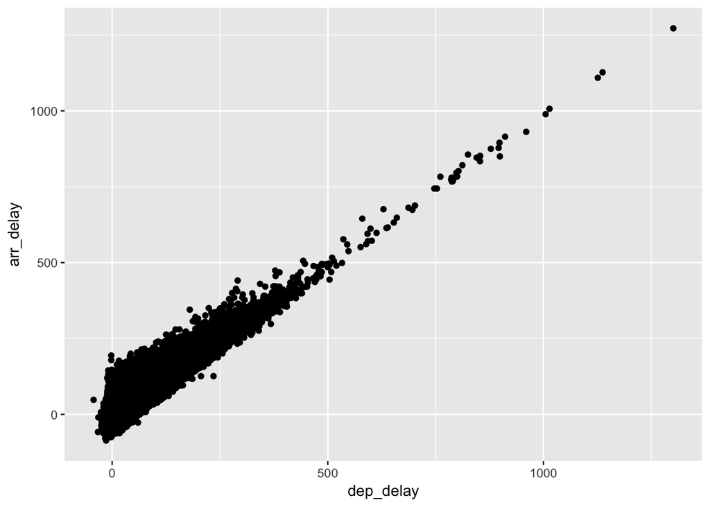

```r
ggplot(flights,aes(x=dep_delay,y=arr_delay)) +
  geom_point()
```

Now let’s work through a final example that involves both data manipulation and some more statistical tests. Let’s say we want to find out whether or not there is any difference in the proportion of delayed flights among the three airports, where we are only concerned whether a flight is delayed (departure delay) or on time, rather than how delayed a flight is. What would you do?

First, we need to create a new column in our dataframe, categorizing flights as delayed or not (1 = delayed, 0 = ontime). Hint: use `mutate()` and `ifelse()`.

```r
flights <- flights %>%
  mutate(delayed = ifelse(dep_delay > 0,1,0))
```

Next, let’s get a sense of how many flights have a departure delay in the dataset, grouped by origin.

Hint: you will need to filter out any missing values.

```r
flights %>%
  group_by(origin) %>%
  filter(!is.na(delayed)) %>%
  summarize(dep_prop = 100*mean(delayed))
```

```
## # A tibble: 3 x 2
##   origin dep_prop
##    <chr>    <dbl>
## 1    EWR 44.82380
## 2    JFK 38.41394
## 3    LGA 33.18918
```

It seems like EWR might have a higher proportion of delayed departures compared to the others. Let’s test this with a chi-squared test. First, we need to make a table of the number of delayed flights by origin, then pass this to a chi-sq test.

```r
flights %>%
  filter(!is.na(delayed)) %>%
  with(.,table(origin,delayed))
```

```
##       delayed
## origin     0     1
##    EWR 64885 52711
##    JFK 67385 42031
##    LGA 67819 33690
```

```r
#to test non-independence using an RxC chisquare test, use chisq.test
flights %>%
  filter(!is.na(delayed)) %>%
  with(.,table(origin,delayed)) %>%
  chisq.test()
```

```
##
##  Pearson's Chi-squared test
##
## data:  .
## X-squared = 3129.1, df = 2, p-value < 2.2e-16
```

## Loops and Conditional Statements

### For Loops

Sometimes you will have a vector, object, or list of objects, where you will want to perform the same series of actions on each member of an object. For this, we can use a `for` loop.

For example, let’s create an R object type we have not yet used, a list. A list is similar to a vector, but the objects of a list do not have to be of the same type. For example, let’s create three numeric vectors with 5 different numbers in each, and then use the `list()` function to group them into a list.

```r
vec1 <- c(1, 5, 2, 6, 9)
vec2 <- c(17, 4, 6, 81, 34)
vec3 <- c(17, 34, 62, 5, 1)

list1 <- list(vec1,vec2,vec3)
```

If you look at list1, you can see all three vectors, and notice that you can subset them with `[[]]`. For example, to pull the third object in the list, you would use `list1[[3]]`.

```r
list1[[3]]
```

```
## [1] 17 34 62  5  1
```

Now, we are going to use a for loop to iterate through this list and calculate the mean of each list. Everything in between the brackets of the for loop will be performed before moving on to the next item in the list.

```r
for (vec in list1){
  print(mean(vec))
}
```

```
## [1] 4.6
## [1] 28.4
## [1] 23.8
```

Note that this is useful, but sometimes rather than iterating through the objects themselves, it is useful to iterate through a vector of numbers, so you can still access each item, but save the results to a new vector. For example:

```r
#Create a new empty vector
mean_vec <- vector()

for (i in 1:length(list1)){
  mean_vec[i] <- mean(list1[[i]])
}

mean_vec
```

```
## [1]  4.6 28.4 23.8
```

You see that we use **i** to stand in for the number in the sequence. It is also always better to calculate the numbers to iterate through based on the length of you object, rather than hard coding (e.g. 1:3). That way if you update your object later, you don’t have to worry about changing your for loop.

### If Statements

If statements (also known as flow control) are also useful, particularly when working with for loops or writing functions (as you will see below). Similar to the `ifelse()` function we used above, we will write a statement where if (something is true) {do everything in the brackets} else {do something else}.

```r
vec4 <- c(1, 5, 3, 9, 1, 9, 3)

list2 <- list(vec1,vec2,vec3,vec4)

for (vec in list2){
  if (length(vec) <= 5){
    print("This vector is no longer than 5 elements")
  }
  else {
    print("This vector is longer than 5 elements")
  }
}
```

```
## [1] "This vector is no longer than 5 elements"
## [1] "This vector is no longer than 5 elements"
## [1] "This vector is no longer than 5 elements"
## [1] "This vector is longer than 5 elements"
```

### Loops and Conditional Exercise 1

For our list2, loop through and calculate the maximum value of each vector.

```r
max_val <- vector()

for (i in 1:length(list2)){
  max_val[i] <- max(list2[[i]])
}
```

### Loops and Conditional Exercise 2

Create a combination of loops and if statements that will take list2, and print the mean value to screen only if the maximum value is greater than 20. Otherwise have it print “Maximum value of vector not great enough”.

```r
for (i in 1:length(list2)){
  if (max(list2[[i]]) > 20){
    print(mean(list2[[i]]))
  }
  else {
    print("Maximum value of vector not great enough")
  }
}
```

```
## [1] "Maximum value of vector not great enough"
## [1] 28.4
## [1] 23.8
## [1] "Maximum value of vector not great enough"
```

## Functions

Tidy data is of course extremely useful. But in order to take full advantage of nicely organized data, you will often need to write your own functions to operate on it.

Simply put, custom functions are easy ways to package your code for reuse. If you find that you are running a specific set of analysis steps on many data subsets, or many files, it is cleaner and easier to maintain if you move the analysis to a set of functions that can be run with input.

It is easy to find the code for the functions you use - just type the name of the functions without parentheses:

```r
ls
```

```
## function (name, pos = -1L, envir = as.environment(pos), all.names = FALSE,
##     pattern, sorted = TRUE)
## {
##     if (!missing(name)) {
##         pos <- tryCatch(name, error = function(e) e)
##         if (inherits(pos, "error")) {
##             name <- substitute(name)
##             if (!is.character(name))
##                 name <- deparse(name)
##             warning(gettextf("%s converted to character string",
##                 sQuote(name)), domain = NA)
##             pos <- name
##         }
##     }
##     all.names <- .Internal(ls(envir, all.names, sorted))
##     if (!missing(pattern)) {
##         if ((ll <- length(grep("[", pattern, fixed = TRUE))) &&
##             ll != length(grep("]", pattern, fixed = TRUE))) {
##             if (pattern == "[") {
##                 pattern <- "\\["
##                 warning("replaced regular expression pattern '[' by  '\\\\['")
##             }
##             else if (length(grep("[^\\\\]\\[<-", pattern))) {
##                 pattern <- sub("\\[<-", "\\\\\\[<-", pattern)
##                 warning("replaced '[<-' by '\\\\[<-' in regular expression pattern")
##             }
##         }
##         grep(pattern, all.names, value = TRUE)
##     }
##     else all.names
## }
## <bytecode: 0x7fcf82833840>
## <environment: namespace:base>
```

To get started writing custom functions, we’ll do some very simple things. For example, R has no built in function to calculate the geometric mean of a vector of numbers. We can write one, like this:

```r
geoMean <- function(x) {
  prod(x)^(1/length(x))
}

test_vec = rnorm(100,5,2)
geoMean(test_vec)
```

```
## [1] 4.561687
```

Just like data, we are assigning the funtion to an object, geoMean. We can then call the geoMean function just like built in R functions, e.g. mean(). Note that unlike mean (which has a trim option and an na.rm option), we currently don’t have any options besides the required option x, a numeric vector.

### Functions Exercise 1:

Write a simple function to calculate the standard deviation of a vector. It should take one required input, a vector, and return the square root of the variance, which you can compute using the sqrt and var functions.

Try running it on test_vec, you should get something close to 2

```
## [1] 1.808738
```

We can add additional options, say to control how missing data is handled. E.g., let’s add the removeNA option, with a default of TRUE, to our geoMean function.

```r
geoMean <- function(x, removeNA=TRUE) {
  if (removeNA) {
    y=x[!is.na(x)]
    prod(y)^(1/length(y))
  } else {
    prod(x)^(1/length(x))
  }
}

test_vec2 = c(test_vec,NA)
geoMean(test_vec)
```

```
## [1] 4.561687
```

```r
geoMean(test_vec2)
```

```
## [1] 4.561687
```

```r
geoMean(test_vec2, removeNA=FALSE)
```

```
## [1] NA
```

### Functions Exercise 2

Rewrite your stDev() function to include a removeNA option with the default being FALSE

Note that we use if {} else {} for flow control here. Flow control options like this are rarely useful in R outside of functions, but can be quite useful inside them, especially to make options work.

You can also nest functions. A function created instead another function will be available in the function, but not outside the function.

```r
allMeans <- function(x, method="arithmetic", removeNA=TRUE) {
  harmMean <- function(x, removeNA=TRUE) {
    if (removeNA) {
      y=x[!is.na(x)]
      length(y)/sum(1/y)
    } else {
      length(x)/sum(1/x)
    }
  }

  means<-list()
  means[['arithmetic']] = mean(x, na.rm=removeNA)
  means[['harmonic']] = harmMean(x, removeNA=removeNA)
  means[['geometic']] = geoMean(x, removeNA=removeNA)

  if ("all" %in% c(method)) {
    return(means)
  }
  else {
    return(means[method])
  }
}
```

We can’t use harmMean without going through allMeans. Try it, you’ll get an error.

```r
allMeans(test_vec, method="harmonic")
```

```
## $harmonic
## [1] 3.176505
```

```r
allMeans(test_vec2, method="all", removeNA = FALSE)
```

```
## $arithmetic
## [1] NA
##
## $harmonic
## [1] NA
##
## $geometic
## [1] NA
```

```r
allMeans(test_vec2, method="all", removeNA = TRUE)
```

```
## $arithmetic
## [1] 5.0288
##
## $harmonic
## [1] 3.176505
##
## $geometic
## [1] 4.561687
```

## Functions Exercise 3:

Write a new function, similar to allMeans, that computes variance, standard deviation, and the coefficient of variation. Step 1: modify your existing standard deviation function to have a option to remove NAs. (Hint: you can use the na.rm option of variance, like we did with mean in allMeans) Step 2: write a new function (either inside or outside the main all variance function) to compute the coefficient of variation (cv), which is the standard deviation divided by the mean. Step 3: combine it all together to make an allVar function. Step 4: test it on test_vec and test_vec2

```
## $cv
## [1] 0.3596759
##
## $var
## [1] 3.271534
##
## $sd
## [1] 1.808738
```

```
## $cv
## [1] NA
##
## $var
## [1] NA
##
## $sd
## [1] NA
```

This, of course, just scratches the surface of where the combination of tidy data and turning your analysis into functions can go. As a final example, let’s make a custom function that will take aclassification variable, a numeric variable, and a number of permutations, and compute a p-value by permutation (this is not very sophisticated, so don’t use this in production code, it is just an example). We’ll use the flights data as a model.

```r
permutation_p <- function(DF, value, key, test_elem, alpha=0.05, nperm=100) {
  #good idea to make a comment that reminds you what each argument does
  #DF = data frame to operate on
  #value = column of data frame that is the numeric value to test
  #key = column of data frame containing categorical variable
  #test_elem = element we want to compare to others to as whether it is greater or less than
  #alpha = p-value cutoff to compute; we'll report if the test is significant at this threshold
  #nperm = # of permutations

  #function to compute means
  meandiff_perm <- function(v1,v2) {
    v2<-sample(v2)
    mean(v1[v2], na.rm=TRUE) - mean(v1[!v2], na.rm=TRUE)
  }

  repeat_meandiff<-function(n, v1, v2) {
    replicate(n, meandiff_perm(v1=v1, v2=v2))
  }

  v1<-unlist(DF[value])
  v2<-unlist(DF[key]==test_elem)
  realtest = mean(v1[v2], na.rm=TRUE) - mean(v1[!v2], na.rm=TRUE)
  perm_res<-repeat_meandiff(nperm, v1=v1, v2=v2)
  dir = sign(realtest)
  sig = mean(abs(realtest) < abs(perm_res))
  if(sig <= alpha) {
    if(dir < 0) {
      return("down")
    } else {
      return("up")
    }
  } else {
    return("ns")
  }
}

permutation_p(flights, "air_time", "carrier", "HA", nperm=100)
```

```
## [1] "up"
```

It isn’t fast, but you can hopefully see how elaborate this can get. Now we can do something like run this test across different months.

```r
flights %>% group_by(month) %>%
  summarize(AlaskaAir_flighttime_diff = permutation_p(., "air_time", "carrier", "AS", nperm=100))
```

```
## # A tibble: 12 x 2
##    month AlaskaAir_flighttime_diff
##    <int>                     <chr>
##  1     1                        up
##  2     2                        up
##  3     3                        up
##  4     4                        up
##  5     5                        up
##  6     6                        up
##  7     7                        up
##  8     8                        up
##  9     9                        up
## 10    10                        up
## 11    11                        up
## 12    12                        up
```

## R Scripts

Today we have been workign within an R script. These are crucial to use when working in R, because it is documentation of the analyses you ran. When you are working on this project later, you can go back and replicate your analyses, tweak them, or share this with others to reproduce your work.

Sometimes, it is also useful to create R scripts with a set of tasks you want to automate. If you save these tasks in a script, you can either put them on Odyssey to run on the cluster, or execute everything in them. Let’s create a new quick script as an example.

Create a new “test_script.R” with the following: setwd(“~/Dropbox/Informatics/Workshops/”) x <- 1:5 y <- c(5,1,4,11,8) pdf(“test_plot2.pdf”) plot(y ~ x) dev.off()

Save that script, and now you can run it by typing:

```r
#source("test_script.R")
```

### Exercise: write a script to generate a plot of the flights data from scratch

> 0. decide what you want to plot. Anything you want, but has to include at least one column not in the default bus dataset or a subset of the default bus dataset
> 1. load in the data
> 2. make required modifications 2b. change the working directory to a new directory that will have the output (has to already exist on your computer)
> 3. open a pdf device to a file
> 4. make your plot
> 5. close pdf device with dev.off()

To really test your script, you can clear your workspace before running!

```r
#rm(list= ls())
```